# STSCI 5030 - Fall 2018 - HW5 Q4

Harry Lu, dl947

Due Tuesday, December 4, 2018

The data in `rats.csv` contain the results of an longitudinal study of rat growth. Rats were given three different diets and their size (calipers around their heads) were recorded at a number of different times. Each rat grows approximately linearly, but they all start from different sizes and grow at different rates, even in the same group.

Within a group, we can express this as
$$y_{ij}=\beta_0+\beta_{1}t_{ij}+b_{i0}+b_{i1}t_{ij}+\epsilon_{ij}$$
for the measurement of the $i$-th rat at time $t_{ij}$ with random intercept $b_{i0}$ and random slope $b_{i1}$ where we specify $\epsilon_{ij} \sim N(0,\sigma^2_e)$, $b_{i0} \sim N(0,\sigma^2_{b_0})$ and $b_{i1} \sim N(0,\sigma^2_{b_1})$.

```r
library(lme4)
rat=read.csv(file="https://www.harrylu.net/CU/5030/rats.csv",header=TRUE)
rat$GROUP=as.factor(rat$GROUP)
rat$SUBJECT=as.factor(rat$SUBJECT)
```

# a

> Write down a model for $y_{ijk}$ to cover rat $i$ in group $k$ at observation time $j$ in which the *average* growth rate in each group is different between rats.

$$y_{ijk}=\beta_{0k}+\beta_{1k}t_{ij}+b_{0ik}+b_{1ik}t_{ij}+\epsilon_{ijk}$$

# b

> Fit this model in `lme4`, can you conclude that the growth rate is different between different groups?

Model 1 (`l_1`): $y_{ij}=\beta_0+\beta_{1}t_{ij}+b_{i0}+b_{i1}t_{ij}+\epsilon_{ij}$

```r
l_1=lmer(RESPONSE~TIME+(TIME|SUBJECT),data=rat)
summary(l_1)
```

```
## Linear mixed model fit by REML ['lmerMod']
## Formula: RESPONSE ~ TIME + (TIME | SUBJECT)
##    Data: rat
##
## REML criterion at convergence: 1071.7
##
## Scaled residuals:
##      Min       1Q   Median       3Q      Max
## -2.21842 -0.56856 -0.02081  0.64382  2.30665
##
## Random effects:
##  Groups   Name        Variance  Std.Dev. Corr
##  SUBJECT  (Intercept) 2.997e+00 1.731109
##           TIME        1.177e-05 0.003431 1.00
##  Residual             2.730e+00 1.652122
## Number of obs: 251, groups:  SUBJECT, 50
##
## Fixed effects:
##             Estimate Std. Error t value
## (Intercept) 63.16762    0.50308  125.56
## TIME         0.19342    0.00598   32.34
##
## Correlation of Fixed Effects:
##      (Intr)
## TIME -0.798
```

Model 2 (`l_2`): $y_{ijk}=\beta_{0k}+\beta_{1k}t_{ij}+b_{0ik}+b_{1ik}t_{ij}+\epsilon_{ijk}$

```r
l_2=lmer(RESPONSE~TIME*GROUP+(TIME|SUBJECT),data=rat)
summary(l_2)
```

```
## Linear mixed model fit by REML ['lmerMod']
## Formula: RESPONSE ~ TIME * GROUP + (TIME | SUBJECT)
##    Data: rat
##
## REML criterion at convergence: 1075.5
##
## Scaled residuals:
##     Min      1Q  Median      3Q     Max
## -2.2557 -0.5760  0.0376  0.6010  2.2615
##
## Random effects:
##  Groups   Name        Variance  Std.Dev. Corr
##  SUBJECT  (Intercept) 3.008e+00 1.734321
##           TIME        4.155e-06 0.002038 1.00
##  Residual             2.736e+00 1.654158
## Number of obs: 251, groups:  SUBJECT, 50
##
## Fixed effects:
##              Estimate Std. Error t value
## (Intercept) 63.762818   0.827086  77.093
## TIME         0.195049   0.009555  20.414
## GROUP2      -1.006861   1.169718  -0.861
## GROUP3      -1.075659   1.298738  -0.828
## TIME:GROUP2 -0.009665   0.013444  -0.719
## TIME:GROUP3  0.009691   0.015928   0.608
##
## Correlation of Fixed Effects:
##             (Intr) TIME   GROUP2 GROUP3 TIME:GROUP2
## TIME        -0.810
## GROUP2      -0.707  0.573
## GROUP3      -0.637  0.516  0.450
## TIME:GROUP2  0.576 -0.711 -0.805 -0.367
## TIME:GROUP3  0.486 -0.600 -0.344 -0.831  0.426
```

$$H_0:\text{Model 1}=\text{Model 2} \quad\quad H_1:\text{Model 1}\neq\text{Model 2}$$

```r
anova(l_1,l_2)
```

```
## Data: rat
## Models:
## l_1: RESPONSE ~ TIME + (TIME | SUBJECT)
## l_2: RESPONSE ~ TIME * GROUP + (TIME | SUBJECT)
##     Df    AIC    BIC  logLik deviance  Chisq Chi Df Pr(>Chisq)
## l_1  6 1074.8 1095.9 -531.38   1062.8
## l_2 10 1075.0 1110.2 -527.48   1055.0 7.7991      4    0.09922 .
## ---
## Signif. codes:  0 '***' 0.001 '**' 0.01 '*' 0.05 '.' 0.1 ' ' 1
```

The $p$-value (0.09922) has CI level at 0.05, so we do not reject $H_0$, which means that there is no significant difference between Model 1 and Model 2. Factor `GROUP` cannot significantly influence the result. Therefore we cannot conclude that the growth rate is different between different groups.

# c

> Why does it not make sense to compare $\sigma^2_e$ and $\sigma^2_{b_1}$ when looking at how much variation is due to what source? If you did want to compare sources of variation, suggest a way to do it.

$$\begin{align}
\text{Cov}(y_{ij},y_{kl})
&=
\text{Cov}(b_{0i},b_{0k})+\text{Cov}(b_{1i}t_{ij},b_{1k}t_{kl})+\text{Cov}(\epsilon_{ij},\epsilon_{kl})\\
&=
\left\{\begin{array}{l}
{\sigma_{0b}}^2+{t_{ij}}^2{\sigma_{1b}}^2+{\sigma_{\epsilon}}^2 & (i=k,j=l)\\
{\sigma_{0b}}^2+t_{ij}t_{kl}{\sigma_{1b}}^2 & (i=k,j \neq l)\\
0 & (i \neq k,j \neq l)
\end{array}\right.
\end{align}$$

# d

> Produce a scatter plot of the random intercepts versus random slopes for each rat (You can get this from `ranef`). Do these appear related?

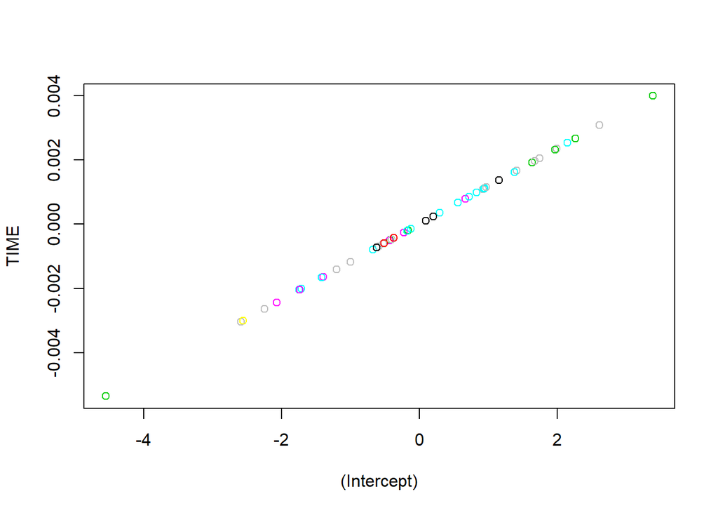

```r
random.effect=ranef(l_2)
plot(random.effect$SUBJECT,col=rat$SUBJECT)
```

There is a positive linear relationship.